# Case Study 2 DDS

Ana Alfaro

## Talent Management Analysis

##### GitHub Repository: https://github.com/GeekyGurlzRock/DDS-Project-2-Ana-Alfaro.git

##### Youtube link: https://youtu.be/xgG7m5eQqLM

In order to improve employee retention and talent management, we will conduct research on employee attributes and explore the characteristics that lead to employee turnover.

### Exploring the data

Evaluating the distribution of employee attrition by department and salary range, it would be assumed that Human Resources has a very good retention pattern.

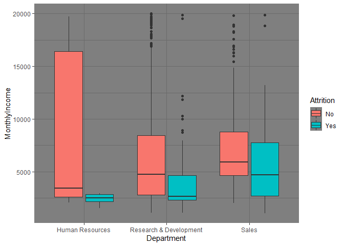

Attrition by Department

Adding employee age to the analysis prompts a disparity to emerge in the Human Resource retention by age data.

There are young employees with low salaries that are disproportionately leaving the human resources department.

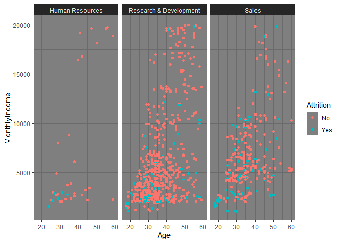

Age Range and Income by Department

Learning more about the job roles held by these employees, it is apparent that they are non-management positions.

The insight gained from identifying these employee’s characteristics can be used to tailor programs and incentives to improve retention in this area.

Success can be measured by tracking retention rates over time for these employees to determine if the programs instituted are effective.

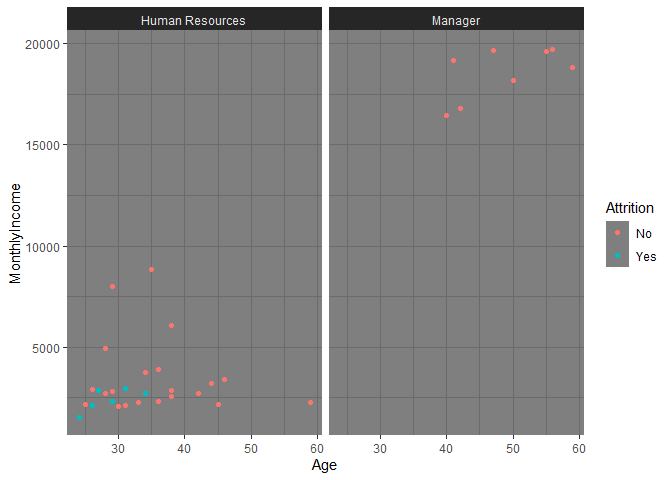

Attrition by Job Role ~ Human Resources

Manipulate this interactive graph to pivot the target employee’s Age vs Income vs Attrition for an increased perspective.

[interactive chart not shown]

Interactive Data Explorer

## Factors that Influence Attrition

### Correlation

Looking at the relationship between the dataset attributes and the response variable, there are not any that stand out, however, there are some that show promise.

Additionally, several attributes towards the end of the dataset seem to be closed aligned to each other.

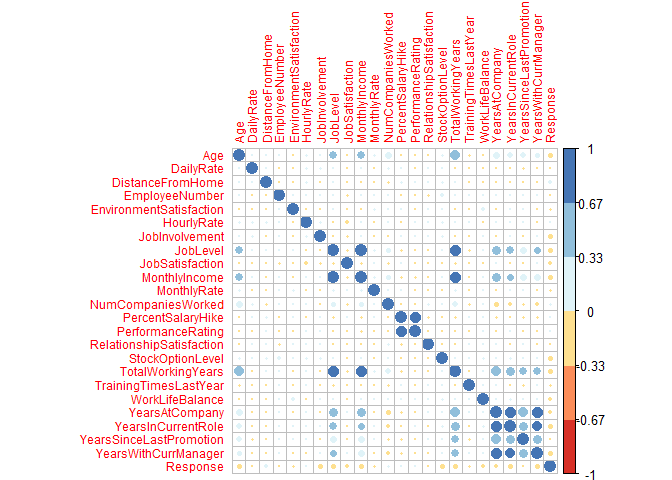

Correlation Plot

### Factors that Influence Attrition

Processed the data using a random forest to identify the factors that are most influential in employee turnover

```
              Influence
MonthlyIncome  19.37489
Age            16.78887
DailyRate      15.24395
```

### Optimize Attrition Classification

Ran an iterative process to identify the number of nearest neighbors that are required to correctly predict employee attrition. It appears the ideal number of nearest neighbors is 1.

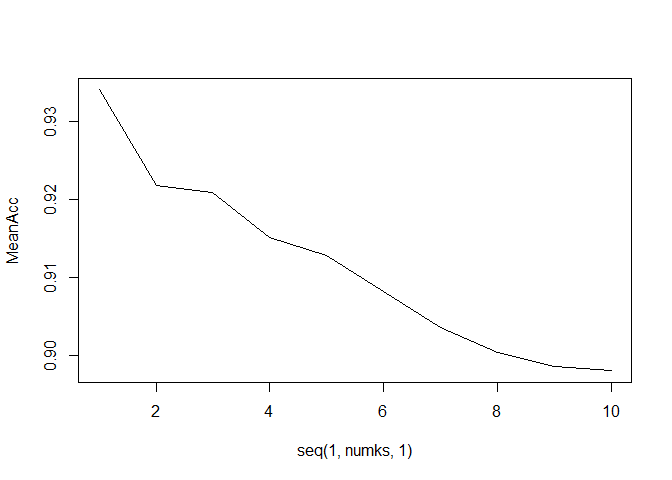

The Mean K-NN Value Line graph

### Attrition Classification Model Metrics

Once we used the optimized nearest neighbor count, we derived the model performance values. The model is performing to spec of > 60% specificity and sensitivity.

```
Confusion Matrix and Statistics


model   0   1
    0 214  12
    1   4  31

               Accuracy : 0.9387
                 95% CI : (0.9024, 0.9646)
    No Information Rate : 0.8352
    P-Value [Acc > NIR] : 4.202e-07

                  Kappa : 0.7593

 Mcnemar's Test P-Value : 0.08012

            Sensitivity : 0.9817
            Specificity : 0.7209
         Pos Pred Value : 0.9469
         Neg Pred Value : 0.8857
             Prevalence : 0.8352
         Detection Rate : 0.8199
   Detection Prevalence : 0.8659
      Balanced Accuracy : 0.8513

       'Positive' Class : 0
```

## Analysing Monthly Income

Next we will explore the attributes that drive employee income.

### Factors that influence income

Using a random forest regression we understand the attributes that are most influential to predict a monthly income.

```
                 Influence
DailyRate         64.48592
EmployeeNumber    64.00250
MonthlyRate       63.69849
HourlyRate        57.78679
Age               55.87540
DistanceFromHome  48.49411
```

#### Linear Model

Employing the attributes that most highly influence monthly income, we develop the following linear regression model.

```
Call:
lm(formula = MINE$MonthlyIncome ~ MINE$EmployeeNumber + MINE$DailyRate +
    MINE$MonthlyRate + MINE$TotalWorkingYears + MINE$Age, data = MINE)

Residuals:
    Min      1Q  Median      3Q     Max
-9566.5 -1620.3   -96.1  1486.9 10997.4

Coefficients:
                         Estimate Std. Error t value Pr(>|t|)
(Intercept)            1376.10322  541.31367   2.542   0.0112 *
MINE$EmployeeNumber       0.11450    0.16219   0.706   0.4804
MINE$DailyRate            0.08724    0.24449   0.357   0.7213
MINE$MonthlyRate          0.01341    0.01383   0.970   0.3324
MINE$TotalWorkingYears  492.53178   17.21616  28.609   <2e-16 ***
MINE$Age                -22.01888   14.50374  -1.518   0.1293
---
Signif. codes:  0 '***' 0.001 '**' 0.01 '*' 0.05 '.' 0.1 ' ' 1

Residual standard error: 2888 on 864 degrees of freedom
Multiple R-squared:  0.6078,    Adjusted R-squared:  0.6055
F-statistic: 267.8 on 5 and 864 DF,  p-value: < 2.2e-16
```

#### RMSE

This model represented a Root Mean Square error below 3000, as specified in the requirements.

```
[1] 2877.755
```

#### Income vs Prediction

It appears the linear regression is most effective at predicting lower income levels.

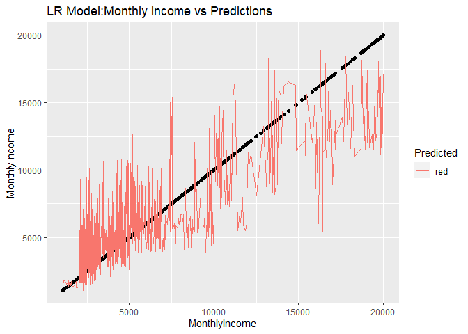

Prediction vs Monthly Income

### Evaluating the regression model ~ coefficient plot

We generated a coefficient plot to evaluate the impact of our regressors on the linear model. It appears all regressors except Total Working Years, were reduced to 0.

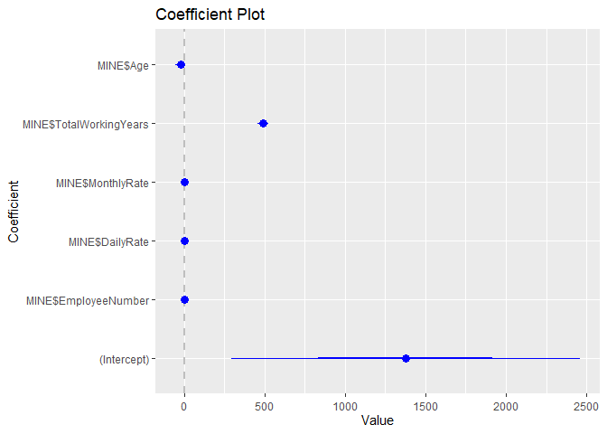

Coefficient Plot

### Evaluating the regression model ~ confidence intervals

We also looked at the confidence intervals and it appears that the intercept confidence interval is quite large.

```
                              2.5 %       97.5 %
(Intercept)            313.65959917 2.438547e+03
MINE$EmployeeNumber     -0.20382739 4.328182e-01
MINE$DailyRate          -0.39261321 5.671021e-01
MINE$MonthlyRate        -0.01373319 4.056095e-02
MINE$TotalWorkingYears 458.74138925 5.263222e+02
MINE$Age               -50.48556190 6.447796e+00
```

## Reduced Model

Evaluating the model it appears that Total Working Years was the regresson that was statistically significant, this was reinforced by the coefficient plot of that regression model.

We attempted a second version of the model, only leaving the regressors that were statistically significant and showed a coefficient larger than 0.

The model performed equally well and it reduced complexity.

```
Call:
lm(formula = MINE$MonthlyIncome ~ MINE$TotalWorkingYears, data = MINE)

Residuals:
    Min      1Q  Median      3Q     Max
-9868.1 -1703.7   -44.5  1453.1 11009.7

Coefficients:
                       Estimate Std. Error t value Pr(>|t|)
(Intercept)             1124.90     174.19   6.458 1.77e-10 ***
MINE$TotalWorkingYears   476.38      13.04  36.544  < 2e-16 ***
---
Signif. codes:  0 '***' 0.001 '**' 0.01 '*' 0.05 '.' 0.1 ' ' 1

Residual standard error: 2887 on 868 degrees of freedom
Multiple R-squared:  0.6061,    Adjusted R-squared:  0.6056
F-statistic:  1335 on 1 and 868 DF,  p-value: < 2.2e-16
```

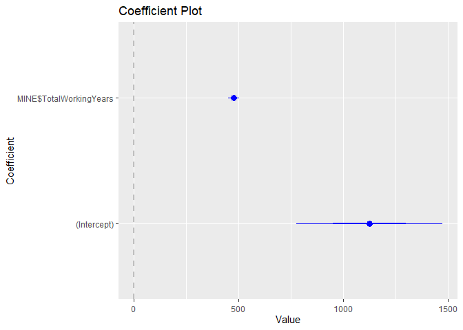

Coefficient Plot New Model

### RMSE New Model

The reduced model also performs to spec with an RMSE lower than 3000, as requested.

```
[1] 2883.996
```

### Evaluating the new model ~ confidence intervals

The confidence intervals for the new model are much more reasonable.

```
                          2.5 %    97.5 %
(Intercept)            783.0205 1466.7815
MINE$TotalWorkingYears 450.7945  501.9647
```

### Conclusion

The data that was examined revealed opportunities for Frito Lay to target specific employee segments in the Human Resources department and improve employee retention. Additionally, there are very good attributes that can identify employess with potential attrition. As demonstrated, complex models are not always required to derive meaningful insights.